# Step 3 Data Manips

Natasha Hardy

17/03/2022

## Workpsace

```r
#R documentation
library(pander)
# general
library(tidyverse)
library(readxl)
library(readr)
library(plyr)
library(dplyr)
library(devtools)
library(here)
"%notin%" = Negate('%in%')
here::here()
```

```
## [1] "/Users/tashhardy/Documents/GitHub/albacore-diet-global"
```

```r
library(lattice)
```

## Load key dataframes

Prey traits, albacore diet and covariates:

```r
prey_trait_select = read.csv(here::here("data/output_data/prey_trait_select.csv"), check.names = FALSE)

alb_global = read.csv(here::here("data/output_data/alb_global_diet.csv"), check.names = FALSE)

alb_covars = read.csv(here::here("data/output_data/alb_covars.csv"), check.names = FALSE)

alb_covars_geog = read.csv(here::here("data/output_data/alb_covars_longhurst.csv"), check.names = FALSE)
```

### Extracting co-variates

Could edit the Longhurst doc to separate biomes and codes as per province definitions: https://en.wikipedia.org/wiki/Longhurst_code#:~:text=Longhurst%20code%20refers%20to%20a,unique%20set%20of%20environmental%20conditions

```r
str(alb_covars_geog)
```

```
## 'data.frame':    70 obs. of  17 variables:
##  $ StudyID         : chr  "Aloncle1973" "Bello1999" "Bello1999" "Bernard1985" ...
##  $ CiteYear        : chr  "1973.0" "1999.0" "1999.0" "1985.0" ...
##  $ OceanBasin      : chr  "N Atlantic" "Mediterranean" "Mediterranean" "N Pacific" ...
##  $ OceanBasinQ     : chr  "NE Atlantic" "Mediterranean" "Mediterranean" "NE Pacific" ...
##  $ LocatName       : chr  "NE Atlantic, Spain, France, Azores" "SW Adriatic" "SW Adriatic" "Southern CA" ...
##  $ LocatLatitude   : num  44.6 41.1 41.2 35.4 48 ...
##  $ LocatLongitude  : num  -5.5 17.5 17.5 -121.9 -11.7 ...
##  $ MonthRange      : chr  "May–Sep" "Sep–Oct" "Sep–Oct" "Aug–Sep" ...
##  $ YearEnd         : int  1971 1992 1994 1983 1928 1929 1930 1931 1932 1933 ...
##  $ stomachs_used   : chr  "1754" "35" "21" "94" ...
##  $ pred_life       : chr  "juvenile" "juvenile" "juvenile" "juvenile" ...
##  $ lat_cat         : chr  "temperate" "temperate" "temperate" "temperate" ...
##  $ pred_life_adjust: chr  "juvenile" "juvenile" "juvenile" "juvenile" ...
##  $ rep_ID          : chr  "Aloncle1973_1" "Bello1999_2" "Bello1999_3" "Bernard1985_4" ...
##  $ province        : chr  "Westerlies - N. Atlantic Drift Province (WWDR)" "Westerlies - Mediterranean Sea, Black Sea Province" "Westerlies - Mediterranean Sea, Black Sea Province" "Coastal - California Upwelling Coastal Province" ...
##  $ code            : chr  "NADR" "MEDI" "MEDI" "CCAL" ...
##  $ optional        : logi  TRUE TRUE TRUE TRUE TRUE TRUE ...
```

```r
str(alb_covars)
```

```
## 'data.frame':    70 obs. of  14 variables:
##  $ StudyID         : chr  "Aloncle1973" "Bello1999" "Bello1999" "Bernard1985" ...
##  $ CiteYear        : chr  "1973.0" "1999.0" "1999.0" "1985.0" ...
##  $ OceanBasin      : chr  "N Atlantic" "Mediterranean" "Mediterranean" "N Pacific" ...
##  $ OceanBasinQ     : chr  "NE Atlantic" "Mediterranean" "Mediterranean" "NE Pacific" ...
##  $ LocatName       : chr  "NE Atlantic, Spain, France, Azores" "SW Adriatic" "SW Adriatic" "Southern CA" ...
##  $ LocatLatitude   : num  44.6 41.1 41.2 35.4 48 ...
##  $ LocatLongitude  : num  -5.5 17.5 17.5 -121.9 -11.7 ...
##  $ MonthRange      : chr  "May–Sep" "Sep–Oct" "Sep–Oct" "Aug–Sep" ...
##  $ YearEnd         : int  1971 1992 1994 1983 1928 1929 1930 1931 1932 1933 ...
##  $ stomachs_used   : chr  "1754" "35" "21" "94" ...
##  $ pred_life       : chr  "juvenile" "juvenile" "juvenile" "juvenile" ...
##  $ lat_cat         : chr  "temperate" "temperate" "temperate" "temperate" ...
##  $ pred_life_adjust: chr  "juvenile" "juvenile" "juvenile" "juvenile" ...
##  $ rep_ID          : chr  "Aloncle1973_1" "Bello1999_2" "Bello1999_3" "Bernard1985_4" ...
```

```r
#Need to merge this with diet data first overall data then probable prey consumed
unique(alb_covars_geog$code)
```

```
##  [1] "NADR" "MEDI" "CCAL" "SATL" "CNRY" "NPTG" "NASW" "NECS" "ISSG" "EAFR"
## [11] "MONS" "NPPF" "ARCH" "SANT" "NEWZ" "SPSG"
```

```r
#check names match
unique(sort(alb_covars_geog$StudyID)) == unique(sort(alb_covars$StudyID)) #they do
```

```
##  [1] TRUE TRUE TRUE TRUE TRUE TRUE TRUE TRUE TRUE TRUE TRUE TRUE TRUE TRUE TRUE
## [16] TRUE TRUE TRUE TRUE TRUE TRUE TRUE TRUE TRUE TRUE TRUE
```

```r
unique(sort(alb_covars_geog$CiteYear)) == unique(sort(alb_covars$CiteYear)) #they do
```

```
##  [1] TRUE TRUE TRUE TRUE TRUE TRUE TRUE TRUE TRUE TRUE TRUE TRUE TRUE TRUE TRUE
## [16] TRUE TRUE TRUE TRUE TRUE TRUE TRUE TRUE TRUE
```

```r
unique(sort(alb_covars_geog$YearEnd)) == unique(sort(alb_covars$YearEnd)) #they do
```

```
##  [1] TRUE TRUE TRUE TRUE TRUE TRUE TRUE TRUE TRUE TRUE TRUE TRUE TRUE TRUE TRUE
## [16] TRUE TRUE TRUE TRUE TRUE TRUE TRUE TRUE TRUE TRUE TRUE TRUE TRUE TRUE TRUE
## [31] TRUE TRUE TRUE TRUE TRUE TRUE
```

```r
unique(sort(alb_covars_geog$MonthRange)) == unique(sort(alb_covars$MonthRange)) #they do!
```

```
##  [1] TRUE TRUE TRUE TRUE TRUE TRUE TRUE TRUE TRUE TRUE TRUE TRUE TRUE TRUE TRUE
## [16] TRUE TRUE TRUE TRUE TRUE TRUE TRUE TRUE TRUE TRUE TRUE TRUE TRUE
```

```r
alb_covars_use = alb_covars_geog %>%
  dplyr::select(-optional, -MonthRange)
```

```r
alb_global_diet = alb_global %>%
  left_join(alb_covars_geog) %>% #looks good #, by = "StudyID"
  dplyr::select(StudyID:YearEnd, rep_ID, province, code, lat_cat, pred_life_adjust,
                stomachs_used:est_ref, prey_class:maxl_type, gape_lmax, gape_height_limit)
```

[output not shown]

```r
unique(alb_global_diet$code)
```

```
##  [1] "NADR" "MEDI" "CCAL" "SATL" "CNRY" "NPTG" "NASW" "NECS" "ISSG" "EAFR"
## [11] "MONS" "NPPF" "ARCH" "SANT" "NEWZ" "SPSG"
```

```r
summary(as.factor(alb_global_diet$code))
```

```
## ARCH CCAL CNRY EAFR ISSG MEDI MONS NADR NASW NECS NEWZ NPPF NPTG SANT SATL SPSG
##   19  312   39   82   71   77   19  332   12    6    1   28   10    2   12    5
```

```r
table(alb_global_diet$code)
```

```
##
## ARCH CCAL CNRY EAFR ISSG MEDI MONS NADR NASW NECS NEWZ NPPF NPTG SANT SATL SPSG
##   19  312   39   82   71   77   19  332   12    6    1   28   10    2   12    5
```

```r
#Write over previous output from first data chunk
write.csv(alb_global_diet, here::here("data/output_data/alb_global_diet_total.csv"),
          row.names = FALSE)
```

## Coavariate data exploration

Supplementary figures S1a/b:

```r
alb_covars_esti = alb_global_diet %>%
  dplyr::select(StudyID, CiteYear, OceanBasin, OceanBasinQ, LocatName, LocatLatitude:pred_flest) %>%
  distinct(StudyID, CiteYear, OceanBasin, OceanBasinQ, LocatName, LocatLatitude,
           LocatLongitude, YearEnd, MonthRange, stomachs_used,
           pred_life, pred_flmean, pred_flmin, pred_flmax, pred_flmean_est, pred_flest) %>%
  pivot_longer(cols = c(pred_flmin, pred_flmean, pred_flmax), names_to = "measurement", values_to = "FL") %>%
  mutate(pred_flest = case_when(pred_flest == "Estimated: by meta-analysis" ~ "Estimated",
                                pred_flest == "Measured: study reported" ~ "Measured"
                                )
         )

unique(alb_covars_esti$measurement)
```

```
## [1] "pred_flmin"  "pred_flmean" "pred_flmax"
```

```r
alb_covars_esti$measurement = factor(alb_covars_esti$measurement,
                                     levels = c("pred_flmin", "pred_flmean", "pred_flmax"),
                                     labels = c("min", "mean", "max"))
levels(alb_covars_esti$measurement)
```

```
## [1] "min"  "mean" "max"
```

```r
unique(alb_covars_esti$pred_flmean_est)
```

```
## [1] "Estimated: by meta-analysis" "Measured: study reported"
```

```r
unique(alb_covars_esti$pred_flest) #use this one
```

```
## [1] "Measured"  "Estimated"
```

```r
unique(alb_covars_esti$StudyID)
```

```
##  [1] "Aloncle1973"             "Bello1999"
##  [3] "Bernard1985"             "Bouxin&Legendre"
##  [5] "Clemens&Iselin1963"      "Consoli2008"
##  [7] "DosSantos&Haimovici2002" "Glaser2015"
##  [9] "Goni2011"                "Hart1948"
## [11] "Iversen1962"             "Jordan1880"
## [13] "Joubin1918"              "Madigan2015"
## [15] "Matthews1977"            "McHugh1952"
## [17] "Monaco1888"              "OrtizZarate1987"
## [19] "Pinkas1971"              "Pusineri2005"
## [21] "Romanov2020"             "Romeo2012"
## [23] "Salman&Karakulak2009"    "Watanabe2004"
## [25] "Williams2015"            "Young2010"
```

```r
alb_covars_esti$StudyID = factor(alb_covars_esti$StudyID,
                                 levels = c("Aloncle1973", "Bello1999", "Bernard1985", "Bouxin&Legendre",
                                            "Clemens&Iselin1963", "Consoli2008", "DosSantos&Haimovici2002", "Glaser2015",
                                            "Goni2011", "Hart1948", "Iversen1962", "Jordan1880",
                                            "Joubin1918", "Madigan2015", "Matthews1977", "McHugh1952",
                                            "Monaco1888", "OrtizZarate1987", "Pinkas1971", "Pusineri2005",
                                            "Romanov2020", "Romeo2012", "Salman&Karakulak2009", "Watanabe2004",
                                            "Williams2015", "Young2010"),
                                 labels = c("Aloncle (1973)•", "Bello (1999)", "Bernard (1985)•", "Bouxin (1934-40)",
                                            "Clemens (1963)", "Consoli (2008)•", "Dos Santos (2002)", "Glaser (2015)",
                                            "Goni (2011)", "Hart (1948)", "Iversen (1962)", "Jordan (1880)",
                                            "Joubin (1918)", "Madigan (2015)", "Matthews (1977)", "McHugh (1952)",
                                            "Monaco (1888)", "Ortiz de Zarate (1987)•", "Pinkas (1971)•", "Pusineri (2005)•",
                                            "Romanov (2020)", "Romeo (2012)•", "Salman (2009)", "Watanabe (2004)•",
                                            "Williams (2015)•", "Young (2010)")
                                 )


levels(as.factor(alb_covars_esti$pred_life))
```

```
## [1] "adult"           "juvenile"        "juvenile, adult"
```

```r
alb_covars_esti$pred_life = factor(alb_covars_esti$pred_life,
                                   levels = c("adult", "juvenile, adult", "juvenile"),
                                   labels = c("adult", "mixed cohort", "juvenile"))
levels(alb_covars_esti$pred_life)
```

```
## [1] "adult"        "mixed cohort" "juvenile"
```

```r
#Save this df for Supplementary Information Section C
```

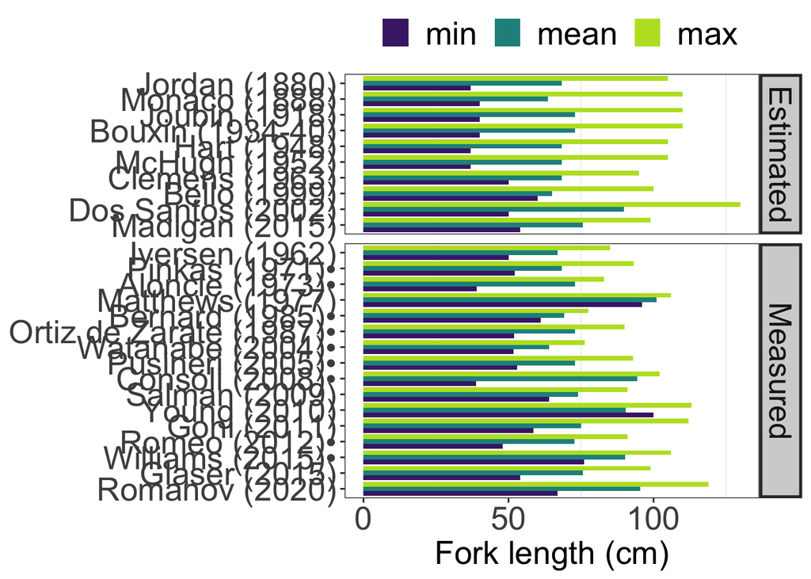

```r
alb_covars_esti_plot <- alb_covars_esti %>%
  mutate(StudyID = fct_reorder(as.factor(StudyID), desc(CiteYear))) %>%
  ggplot(aes(x=StudyID, y=FL, fill=measurement)) +
  geom_bar(stat="identity", position="dodge")+
  #geom_errorbar(data = fish_plot_data_troph, position=position_dodge(0.8),
  #              aes(ymin=mean.abun-SE.abun, ymax=mean.abun+SE.abun), width=.2) +
  scale_fill_viridis_d(name = "",
                       direction = 1,
                       begin = 0.1,
                       end = 0.9,
                       option = 'D',
                       na.value = 'grey')+
  theme_bw()+
  coord_flip()+
  theme(panel.grid.major = element_blank(),
        #axis.ticks = element_blank(),
        #axis.text.x = element_text(angle = 90, vjust = 0.5, hjust=1),
        axis.title.y=element_blank(),
        axis.title.x=element_text(size=20),
        axis.text=element_text(size=20),
        axis.text.x=element_text(size=20),
        axis.text.y=element_text(size=20),
        legend.text=element_text(size=20),
        legend.title=element_text(size=20),
        legend.position="top" #"none"
        ) +
  labs(y = "Fork length (cm)") +
  facet_grid(pred_flest ~ ., space='free', scales="free")+
  theme(strip.text = element_text(size=rel(1.75)), #face="bold",
        strip.background = element_rect(fill="lightgrey", #colour="black",
                                        size=1.75))
alb_covars_esti_plot
```

```r
ggsave(here::here("outputs_figures/ms_figures/alb_covars_size_esti_plot.jpeg"),
       plot = alb_covars_esti_plot, width=8, height=8, dpi=300)
```

```r
alb_covars_esti_SI = alb_global_diet %>%
  dplyr::select(StudyID, CiteYear, OceanBasin, OceanBasinQ, LocatName, LocatLatitude:pred_flest) %>%
  distinct(StudyID, CiteYear, OceanBasin, OceanBasinQ, LocatName, LocatLatitude,
           LocatLongitude, YearEnd, MonthRange, stomachs_used,
           pred_life, pred_flmean, pred_flmin, pred_flmax, pred_flmean_est, pred_flest) #%>%
  #pivot_longer(cols = c(pred_flmin, pred_flmean, pred_flmax), names_to = "measurement", values_to = "FL") %>%
  #mutate(pred_flest = case_when(pred_flest == "Estimated: by meta-analysis" ~ "Estimated",
  #                              pred_flest == "Measured: study reported" ~ "Measured"
  #                              )
  #       )
#Write over previous output from first data chunk
write.csv(alb_covars_esti_SI, here::here("data/output_data/alb_covars_estimates.csv"),
          row.names = FALSE)
```

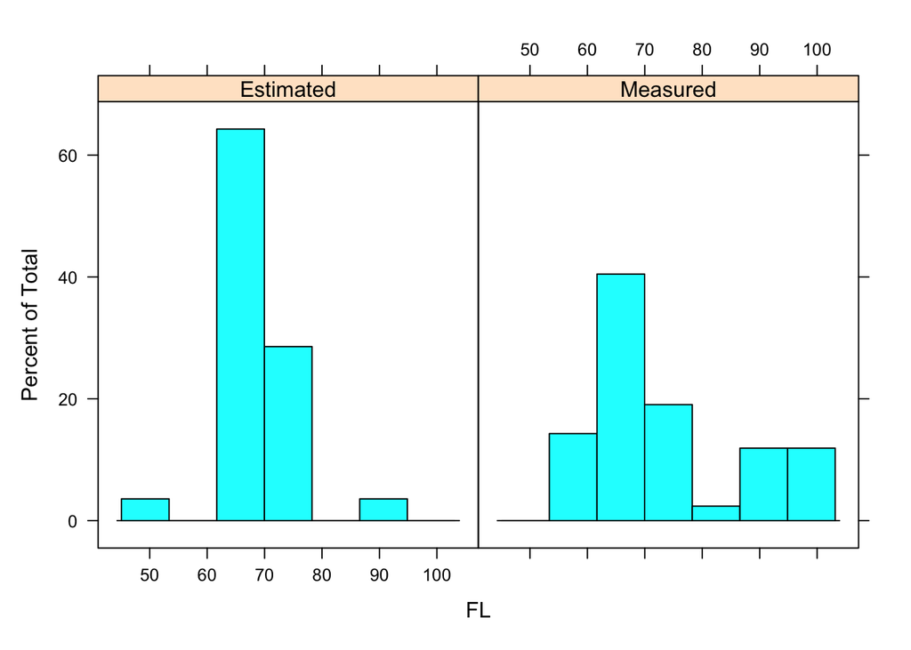

```r
#Check on the spread of the data by mean FL
data = alb_covars_esti %>% filter(measurement == "mean")
#formula = pred_flmean ~ pred_flest
histogram(~ FL | pred_flest, data = data)
```

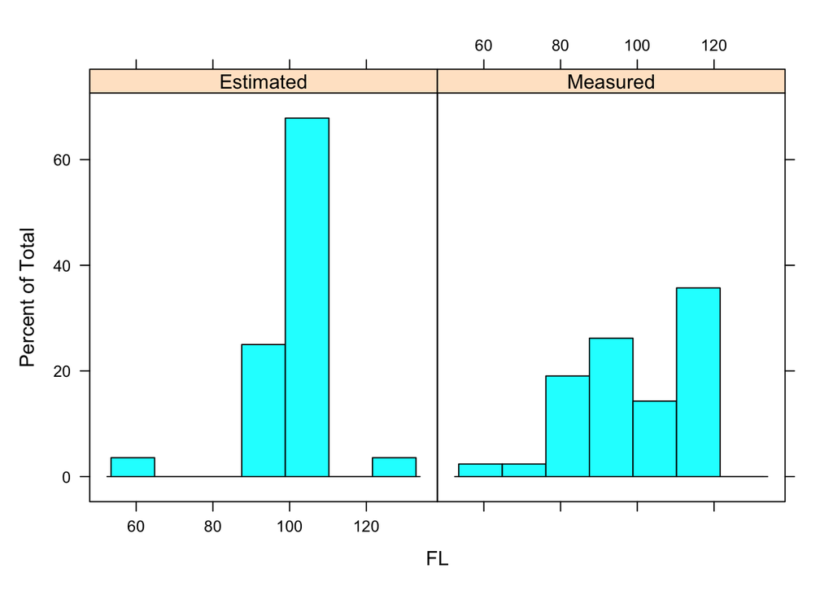

```r
#Check on the spread of the data by max FL
data_max = alb_covars_esti %>% filter(measurement == "max")
#formula = pred_flmean ~ pred_flest
histogram(~ FL | pred_flest, data = data_max)
```

```r
#Run linear regression on FL mean length data in relation to estimated vs. measured data
test_alb_size = lm(FL ~ pred_flest, data = data)

anova(test_alb_size)
```

```
## Analysis of Variance Table
##
## Response: FL
##            Df Sum Sq Mean Sq F value Pr(>F)
## pred_flest  1  274.8  274.79  2.4048 0.1256
## Residuals  68 7770.3  114.27
```

```r
summary(test_alb_size)
```

```
##
## Call:
## lm(formula = FL ~ pred_flest, data = data)
##
## Residuals:
##     Min      1Q  Median      3Q     Max
## -22.267  -6.408  -1.097   3.403  27.459
##
## Coefficients:
##                    Estimate Std. Error t value Pr(>|t|)
## (Intercept)          69.497      2.020  34.402   <2e-16 ***
## pred_flestMeasured    4.044      2.608   1.551    0.126
## ---
## Signif. codes:  0 '***' 0.001 '**' 0.01 '*' 0.05 '.' 0.1 ' ' 1
##
## Residual standard error: 10.69 on 68 degrees of freedom
## Multiple R-squared:  0.03416,    Adjusted R-squared:  0.01995
## F-statistic: 2.405 on 1 and 68 DF,  p-value: 0.1256
```

```r
#Not significant
```

```r
#We need to do this on the replicate level and not the study level
alb_covars_esti_life_plot <- alb_covars_esti %>%
  mutate(StudyID = fct_reorder(as.factor(StudyID), desc(CiteYear))) %>%
  ggplot(aes(x=StudyID, y=FL, fill=measurement)) +
  geom_bar(stat="identity", position="dodge")+
  #geom_errorbar(data = fish_plot_data_troph, position=position_dodge(0.8),
  #              aes(ymin=mean.abun-SE.abun, ymax=mean.abun+SE.abun), width=.2) +
  scale_fill_viridis_d(name = "",
                       direction = 1,
                       begin = 0.1,
                       end = 0.9,
                       option = 'D',
                       na.value = 'grey')+
  theme_bw()+
  coord_flip()+
  theme(panel.grid.major = element_blank(),
        #axis.ticks = element_blank(),
        #axis.text.x = element_text(angle = 90, vjust = 0.5, hjust=1),
        axis.title.y=element_blank(),
        axis.title.x=element_text(size=20),
        axis.text=element_text(size=20),
        axis.text.x=element_text(size=20),
        axis.text.y=element_text(size=20),
        legend.text=element_text(size=20),
        legend.title=element_text(size=20),
        legend.position="top" #"none"
        ) +
  labs(y = "Fork length (cm)") +
  facet_grid(pred_flest ~ pred_life, space='free', scales="free")+
  theme(strip.text = element_text(size=rel(1.75)), #face="bold",
        strip.background = element_rect(fill="lightgrey", #colour="black",
                                        size=1.75))
alb_covars_esti_life_plot

ggsave(here::here("outputs_figures/ms_figures/alb_covars_size_esti_plot2.jpeg"),
       plot = alb_covars_esti_plot, width=8, height=12, dpi=300)
```

[output not shown]

### Diet datasets

Note that there are a handful of cases where the same prey species was consumed and reported for two different life stages. Because this affects three species and for only one study, the simplest solution to be able to move forward, we need to just select the most commonly consumed species/life stage combination.

```r
#Previous problem rows
#View(alb_global_diet[c(192, 226, 111, 118, 204, 247, 99, 117, 227, 248),])
#select 192, 111, 247, 99, 248
#alb_global_diet_use = alb_global_diet %>%
#  slice(., -c(226, 118, 117, 204, 227))

#Updated data was downloaded with different order of the data so these rows have moved
View(alb_global_diet[c(130, 131, 187, 196, 77, 80, 192, 198, 76, 79, 197, 199),])
View(alb_global_diet[c(131, 187, 77, 198, 76, 199),])

#We select to keep the most common one (typically these were the same species appearing in the same study for two different life stages and this only affected the Bouxin & Legendre papers)
alb_global_diet_use = alb_global_diet %>%
  slice(., -c(131, 187, 77, 198, 76, 199))
```

#### Presence/absence

Here we will join our additional covariates (inc. Longhurst province data) with the diet data, and generate a wide format df with species as columns and values for species’ presence absence (PA). These data will be used for traitglms.

```r
#Extract data --> filter for only species that we have adult traits + cluster info for
# --> transform to wide data for MV GLMs + trait GLMs
alb_global_dietpa = alb_global_diet_use %>% #_use
  dplyr::select(#StudyID:stomachs_used, lat_cat:code, pred_life_adjust, pred_flmean, prey_age_reported_1, prey_sp
    StudyID, rep_ID, YearEnd, OceanBasin, OceanBasinQ, province, code, lat_cat,
    pred_life_adjust, prey_sp) %>%
  mutate(pa="1") %>%
  group_by(prey_sp) %>%
  #dplyr::mutate(grouped_id = row_number()) %>%
  spread(prey_sp, pa, fill = 0, convert = FALSE)

#Check covariate representation
summary(as.factor(alb_global_dietpa$lat_cat))
summary(as.factor(alb_global_dietpa$code))
summary(as.factor(alb_global_dietpa$OceanBasin))
summary(as.factor(alb_global_dietpa$OceanBasinQ))

write.csv(alb_global_dietpa, here("data/output_data/alb_global_wide_dietpa.csv"),
          row.names = FALSE)
```

#### Diet data - frequency of occurrence

Here we will join our additional covariates (inc. Longhurst province data) with the diet data, and generate a wide format df with species as columns and values for reported frequency of occurrence (FO). Because these data may be used for traitglms and converted to presence/absence, we filter for very low occurrence species (< 1%).

```r
#Extract %FO data --> filter for only species that we have adult traits +
# cluster info for --> transform to wide data for MV GLMs + trait GLMs

alb_global_dietfo = alb_global_diet_use %>%
  dplyr::select(StudyID, rep_ID, YearEnd, OceanBasin, OceanBasinQ, province, code,
                lat_cat, pred_life_adjust, prey_sp, pFOuse) %>%
  filter(pFOuse >= 1) %>% #set this value to include or exclude species #goes down to 62 observations
  group_by(prey_sp) %>%
  #dplyr::mutate(grouped_id = row_number()) %>%
  spread(prey_sp, pFOuse, fill = 0, convert = FALSE)

#Check these data
which(rowSums(alb_global_dietfo[,10:ncol(alb_global_dietfo)])<1)

#Before spreading data - range(alb_global_dietfo$pFOuse)
#0 to 100 need to exclude zeros as they are not true zeros --> 0.1 to 100%

#Check covariate representation
summary(as.factor(alb_global_dietfo$lat_cat))
summary(as.factor(alb_global_dietfo$code))
summary(as.factor(alb_global_dietfo$OceanBasin))
summary(as.factor(alb_global_dietfo$OceanBasinQ))

write.csv(alb_global_dietfo, here("data/output_data/alb_global_wide_dietfo.csv"),
          row.names = FALSE)
```

#### Diet data - abundance

```r
#Extract for %N data
alb_global_dietn = alb_global_diet_use %>%
  dplyr::select(StudyID, rep_ID, YearEnd, OceanBasin, OceanBasinQ, province, code, lat_cat, pred_life_adjust, prey_sp, pN) %>%
  filter(pN > 0) %>%
  #filter(prey_sp %in% alb_adult_traits$prey_sp) %>%
  group_by(prey_sp) %>%
  spread(prey_sp, pN, fill = 0, convert = FALSE)

#Check covariate representation
summary(as.factor(alb_global_dietn$lat_cat))
summary(as.factor(alb_global_dietn$code))
summary(as.factor(alb_global_dietn$OceanBasin))
summary(as.factor(alb_global_dietn$OceanBasinQ))

write.csv(alb_global_dietn, here("data/output_data/alb_global_wide_dietn.csv"), row.names = FALSE)
```

#### Diet data - biomass

```r
#Extract for %M data
#range(alb_global_dietm$pM) #0 to 95.2, need to exclude zeros as not true zeros

alb_global_dietm = alb_global_diet %>%
  dplyr::select(StudyID, rep_ID, YearEnd, OceanBasin, OceanBasinQ, province, code, lat_cat, pred_life_adjust, prey_sp, pM) %>%
  filter(pM > 0) %>%
#  filter(prey_sp %in% alb_adult_traits$prey_sp) %>%
  group_by(prey_sp) %>%
  spread(prey_sp, pM, fill = 0, convert = FALSE)

#Check covariate representation
summary(as.factor(alb_global_dietm$lat_cat))
summary(as.factor(alb_global_dietm$code))
summary(as.factor(alb_global_dietm$OceanBasin))
summary(as.factor(alb_global_dietm$OceanBasinQ))

write.csv(alb_global_dietm, here("data/output_data/alb_global_wide_dietm.csv"), row.names = FALSE)
```

### Extra from older code

```r
#Can use prey_morph_sum for "standard_total" conversion info for SL to TL.
  #left_join(prey_morph_sum, by="prey_sp")
  #added morph info --> 1028 obs, 44 vars

#Cleaning metrics
alb_global = alb_global %>%
  mutate(maxtl_use = if_else(alb_global$maxl_type %in% c("SL", "ML"),
                             maxl_use/standard_total, maxl_use)
         ) #%>%
```